# Assignment 5 Data Report

# Mass shootings in 2018: a data report

Gun violence has quickly become one of the most prominent issues in the US over the past decade.

According to the Gun Violence Archive’s (GVA) [2018 report](https://www.gunviolencearchive.org/reports/mass-shooting), there were a total of 340 reported incidents. The shootings caused a total of 373 lives lost. The city that was most impacted by shootings in 2018 was Pompano Beach (Parkland), Florida (impact is analyzed by the amount of lives lost in shootings, however, it is respectfully recognized that some reports may calculate impact by injuries). The state that was most impacted by shootings in 2018 was California. It was also found that the month with the most reported shootings was June.

## Summary of GVA 2018 Shooting Data

| State | Total Victims | Deaths | Injuries | Death Percentage | Injury Percentage |
| --- | --- | --- | --- | --- | --- |
| Alabama | 67 | 12 | 55 | 18 | 82 |
| Arizona | 9 | 4 | 5 | 44 | 56 |
| Arkansas | 24 | 7 | 17 | 29 | 71 |
| California | 186 | 50 | 136 | 27 | 73 |
| Colorado | 36 | 9 | 27 | 25 | 75 |
| Connecticut | 8 | 0 | 8 | 0 | 100 |
| Delaware | 5 | 5 | 0 | 100 | 0 |
| District of Columbia | 25 | 2 | 23 | 8 | 92 |
| Florida | 180 | 48 | 132 | 27 | 73 |
| Georgia | 36 | 3 | 33 | 8 | 92 |
| Illinois | 171 | 21 | 150 | 12 | 88 |
| Indiana | 37 | 10 | 27 | 27 | 73 |
| Kansas | 12 | 1 | 11 | 8 | 92 |
| Kentucky | 32 | 7 | 25 | 22 | 78 |
| Louisiana | 65 | 15 | 50 | 23 | 77 |
| Maryland | 44 | 13 | 31 | 30 | 70 |
| Massachusetts | 4 | 0 | 4 | 0 | 100 |
| Michigan | 38 | 10 | 28 | 26 | 74 |
| Minnesota | 15 | 1 | 14 | 7 | 93 |
| Mississippi | 18 | 1 | 17 | 6 | 94 |
| Missouri | 64 | 12 | 52 | 19 | 81 |
| Nebraska | 17 | 1 | 16 | 6 | 94 |
| Nevada | 18 | 3 | 15 | 17 | 83 |
| New Jersey | 58 | 4 | 54 | 7 | 93 |
| New Mexico | 9 | 5 | 4 | 56 | 44 |
| New York | 58 | 5 | 53 | 9 | 91 |
| North Carolina | 51 | 14 | 37 | 27 | 73 |
| Ohio | 59 | 13 | 46 | 22 | 78 |
| Oklahoma | 21 | 2 | 19 | 10 | 90 |
| Pennsylvania | 98 | 35 | 63 | 36 | 64 |
| South Carolina | 24 | 5 | 19 | 21 | 79 |
| Tennessee | 87 | 19 | 68 | 22 | 78 |
| Texas | 91 | 29 | 62 | 32 | 68 |
| Utah | 4 | 0 | 4 | 0 | 100 |
| Virginia | 19 | 2 | 17 | 11 | 89 |
| Washington | 13 | 4 | 9 | 31 | 69 |
| Wisconsin | 17 | 1 | 16 | 6 | 94 |

Many of the state injury to death ratios favor injuries, but there still are some states that show the opposite where there are more deaths than injuries. However, it should be noted that these states usually have lower victim totals, indicating that there could be a positive correlation between total victims and the ratio of injuries to deaths.

## Many mass shootings means many unfortunate victims

On June 17, 2018, a shooting occurred in Trenton, New Jersey. This incident - that happened at 635 S Clinton Ave - would become one of the most prominent shootings of the year, totaling up to 19 and 1. These 20 victims were the result of the worst shooting that year according to the amount of reported injuries. The shooting was one of 2 shootings that happened in Trenton that month.

A link to the report on the shooting incident can be found [here](https://www.nytimes.com/2018/06/17/nyregion/trenton-mass-shooting.html) (note that data from this report might differ slightly from the given link).

## Incident map

The map below represents the shooting locations according to the 2018 GVA report. The size of the circle represents the number of victims during the incident relative to other incidents.

[interactive chart not shown]

As seen from a geographical view, the majority of the larger mass shootings of 2018 happened on the east coast, with a very concentrated amount of incident reports in the Maryland/New Jersey/Pennsylvania area. The largest concentration of incident reports on the west coast are seen in the LA area. However, if we take a look at the same data from a different angle, we see a very different story.

## Analysis by state

As seen above, states saw varying levels of activity in 2018. The states that experienced mass shootings had differing numbers of victims, and of those victims, had differing ratios of casualties to injuries. However, the geographical perspective was less effective at showing how areas with high concentration of shooting reports were really effected.

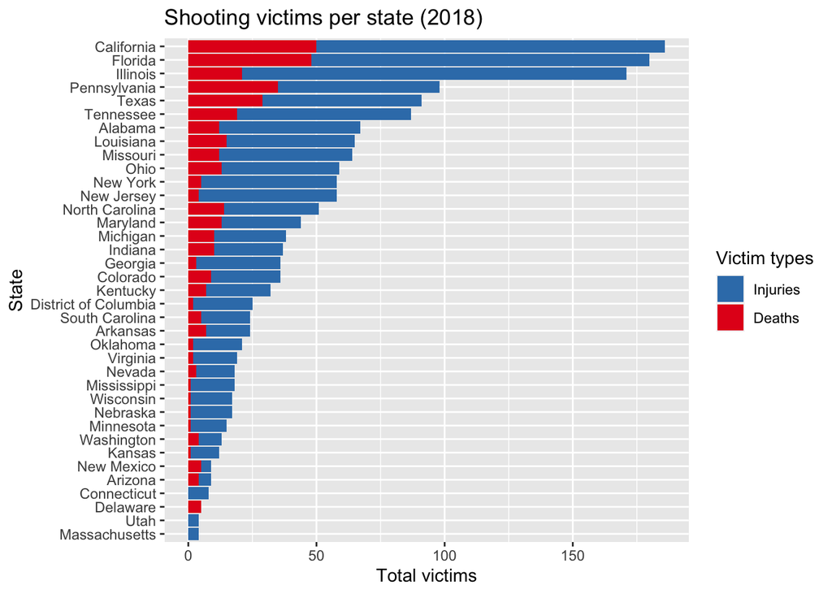

A horizontal bar chart was chosen to reflect the number of victims in each state. Notice that the chart is also stacked with both number of injuries and deaths for each state. This allows viewers to more easily compare the number of victims to each state than the map above. For example, the map shows a high concentration of dots in the north eastern area of the US, however, it’s obvious according to the bar chart that both California and Florida had the most victims. Note: this may not necessarily mean that there were more shootings in those states than the north eastern states; another chart should be made to explicitly compare shooting incident density. Although, the map may not have been extremely effective, it still managed to depict some of the data correctly. Pennsylvania, a north eastern state, had the most victims per state of those under 100 victims.

By Christian Cruz

INFO 201 SPRING 2020